# R Notebook

# Budweiser Data Analysis Report

Refer to [@naivelogic github page](https://github.com/naivelogic/MSDS-6306-Case-Study-01-Budweiser) for details on analysis and [data dictionary](https://github.com/naivelogic/MSDS-6306-Case-Study-01-Budweiser#appendix)

[figure not shown]

**Import `beers` dataset**

```r
beer = read.csv("https://raw.githubusercontent.com/naivelogic/MSDS-6306-Case-Study-01-Budweiser/master/data/Beers.csv")
head(beer)
```

|  | Name | Beer_ID | ABV | IBU | Brewery_id | Style | Ounces |
| --- | --- | --- | --- | --- | --- | --- | --- |
| 1 | Pub Beer | 1436 | 0.050 | NA | 409 | American Pale Lager | 12 |
| 2 | Devil's Cup | 2265 | 0.066 | NA | 178 | American Pale Ale (APA) | 12 |
| 3 | Rise of the Phoenix | 2264 | 0.071 | NA | 178 | American IPA | 12 |
| 4 | Sinister | 2263 | 0.090 | NA | 178 | American Double / Imperial IPA | 12 |
| 5 | Sex and Candy | 2262 | 0.075 | NA | 178 | American IPA | 12 |
| 6 | Black Exodus | 2261 | 0.077 | NA | 178 | Oatmeal Stout | 12 |

**Import `Breweries` dataset**

```r
brew = read.csv("C:/Users/phhale/OneDrive - Southern Methodist University/MSDS 6306 Doing Data Science/lol/MSDS-6306-Case-Study-01-Budweiser/data/Breweries.csv")
head(brew)
```

|  | Brew_ID | Name | City | State | region |
| --- | --- | --- | --- | --- | --- |
| 1 | 1 | NorthGate Brewing | Minneapolis | MN | Midwest |
| 2 | 2 | Against the Grain Brewery | Louisville | KY | South |
| 3 | 3 | Jack's Abby Craft Lagers | Framingham | MA | Northeast |
| 4 | 4 | Mike Hess Brewing Company | San Diego | CA | West |
| 5 | 5 | Fort Point Beer Company | San Francisco | CA | West |
| 6 | 6 | COAST Brewing Company | Charleston | SC | South |

```r
# regions
```

> 1. How many breweries are present in each state?

```r
brew_freq = as.data.frame(sort(table(brew$State),decreasing=TRUE))
names(brew_freq) = c('state', 'freq')
sort(table(brew$State), decreasing=TRUE)
```

```
##
## CO CA MI OR TX PA MA WA IN WI NC IL NY VA FL OH MN AZ VT ME MO MT CT AK GA
## 47 39 32 29 28 25 23 23 22 20 19 18 16 16 15 15 12 11 10  9  9  9  8  7  7
## MD OK IA ID LA NE RI HI KY NM SC UT WY AL KS NH NJ TN AR DE MS NV DC ND SD
##  7  6  5  5  5  5  5  4  4  4  4  4  4  3  3  3  3  3  2  2  2  2  1  1  1
## WV
##  1
```

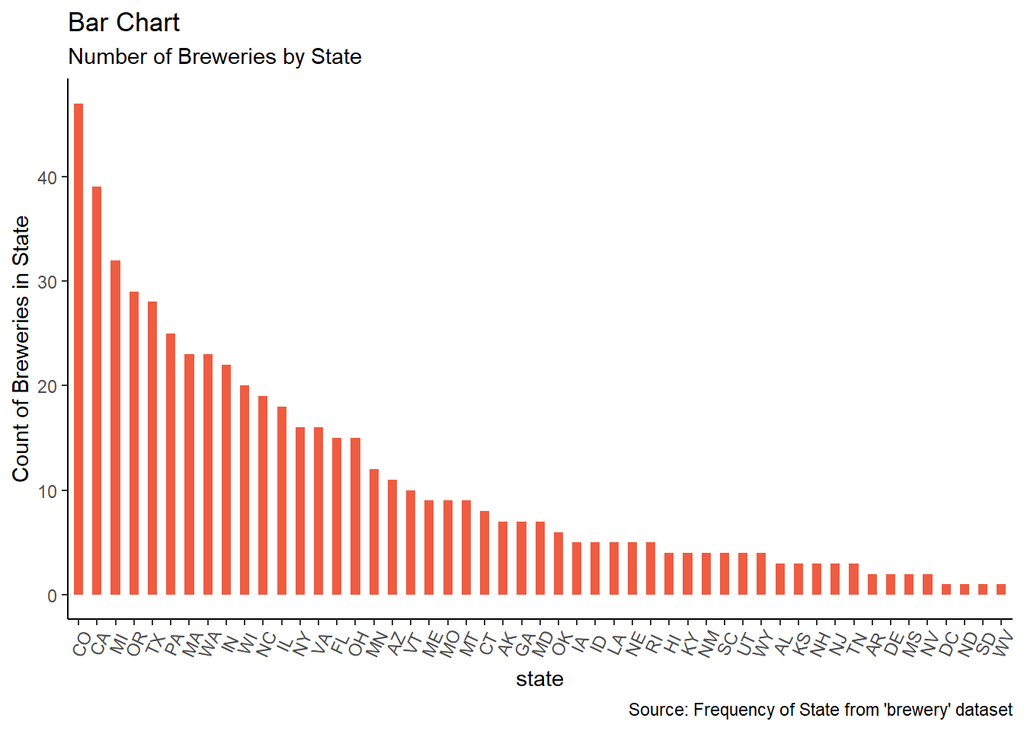

```r
library(ggplot2)
library(scales)
theme_set(theme_classic())

# inspired - http://r-statistics.co/Top50-Ggplot2-Visualizations-MasterList-R-Code.html


# Plot
ggplot(brew_freq, aes(state, freq)) + geom_bar(stat="identity", width = 0.5, fill="tomato2") +
   ylab("Count of Breweries in State")+
      labs(title="Bar Chart",
           subtitle="Number of Breweries by State",
           caption="Source: Frequency of State from 'brewery' dataset") +
      theme(axis.text.x = element_text(angle=65, vjust=0.6))
```

> 2. Merge beer data with the breweries data. Print the first 6 observations and the last six observations to check the merged file.

```r
df = merge(beer, brew, by.x = "Brewery_id", by.y = "Brew_ID")
head(df, 6)
```

|  | Brewery_id | Name.x | Beer_ID | ABV | IBU | Style | Ounces | Name.y | City | State | region |
| --- | --- | --- | --- | --- | --- | --- | --- | --- | --- | --- | --- |
| 1 | 1 | Get Together | 2692 | 0.045 | 50 | American IPA | 16 | NorthGate Brewing | Minneapolis | MN | Midwest |
| 2 | 1 | Maggie's Leap | 2691 | 0.049 | 26 | Milk / Sweet Stout | 16 | NorthGate Brewing | Minneapolis | MN | Midwest |
| 3 | 1 | Wall's End | 2690 | 0.048 | 19 | English Brown Ale | 16 | NorthGate Brewing | Minneapolis | MN | Midwest |
| 4 | 1 | Pumpion | 2689 | 0.060 | 38 | Pumpkin Ale | 16 | NorthGate Brewing | Minneapolis | MN | Midwest |
| 5 | 1 | Stronghold | 2688 | 0.060 | 25 | American Porter | 16 | NorthGate Brewing | Minneapolis | MN | Midwest |
| 6 | 1 | Parapet ESB | 2687 | 0.056 | 47 | Extra Special / Strong Bitter (ESB) | 16 | NorthGate Brewing | Minneapolis | MN | Midwest |

```r
tail(df, 6)
```

|  | Brewery_id | Name.x | Beer_ID | ABV | IBU | Style | Ounces | Name.y | City | State | region |
| --- | --- | --- | --- | --- | --- | --- | --- | --- | --- | --- | --- |
| 2405 | 556 | Pilsner Ukiah | 98 | 0.055 | NA | German Pilsener | 12 | Ukiah Brewing Company | Ukiah | CA | West |
| 2406 | 557 | Heinnieweisse Weissebier | 52 | 0.049 | NA | Hefeweizen | 12 | Butternuts Beer and Ale | Garrattsville | NY | Northeast |
| 2407 | 557 | Snapperhead IPA | 51 | 0.068 | NA | American IPA | 12 | Butternuts Beer and Ale | Garrattsville | NY | Northeast |
| 2408 | 557 | Moo Thunder Stout | 50 | 0.049 | NA | Milk / Sweet Stout | 12 | Butternuts Beer and Ale | Garrattsville | NY | Northeast |
| 2409 | 557 | Porkslap Pale Ale | 49 | 0.043 | NA | American Pale Ale (APA) | 12 | Butternuts Beer and Ale | Garrattsville | NY | Northeast |
| 2410 | 558 | Urban Wilderness Pale Ale | 30 | 0.049 | NA | English Pale Ale | 12 | Sleeping Lady Brewing Company | Anchorage | AK | West |

> 3. Report the number of NA’s in each column.

```r
# Missing values
colSums(is.na(df))
```

```
## Brewery_id     Name.x    Beer_ID        ABV        IBU      Style
##          0          0          0         62       1005          0
##     Ounces     Name.y       City      State     region
##          0          0          0          0          0
```

We can see that IBU has 1005 NAs and ABV has 62 NAs. It could be possible to do some mean/median imputation for inference in these missing values. however it would be questionable given this size of the data set and how many are missing especially from `IBU`.

> 4. Compute the median alcohol content and international bitterness unit for each state. Plot a bar chart to compare.

```r
library(dplyr)
abv_ibu =df %>%
  group_by(State, region) %>%
  summarise_at(vars("ABV", "IBU"), funs(median(., na.rm=TRUE)))
head(abv_ibu)
```

| State | region | ABV | IBU |
| --- | --- | --- | --- |
| AK | West | 0.0560 | 46.0 |
| AL | South | 0.0600 | 43.0 |
| AR | South | 0.0520 | 39.0 |
| AZ | West | 0.0550 | 20.5 |
| CA | West | 0.0580 | 42.0 |
| CO | West | 0.0605 | 40.0 |

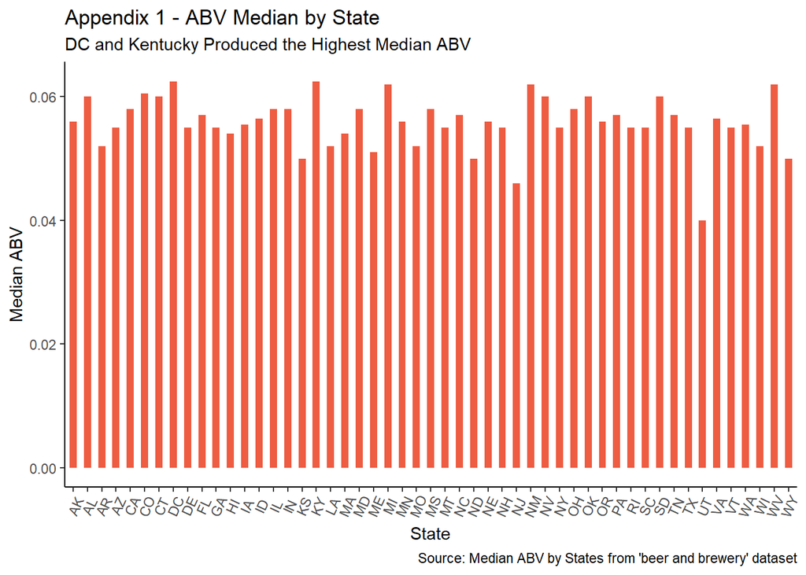

```r
# Plot
ggplot(abv_ibu, aes(State, ABV)) + geom_bar(stat="identity", width = 0.5, fill="tomato2")+
    ylab("Median ABV")+
      labs(title="Appendix 1 - ABV Median by State",
           subtitle="DC and Kentucky Produced the Highest Median ABV",
           caption="Source: Median ABV by States from 'beer and brewery' dataset") +
      theme(axis.text.x = element_text(angle=65, vjust=0.6))
```

DC and Kentucky highest ABV

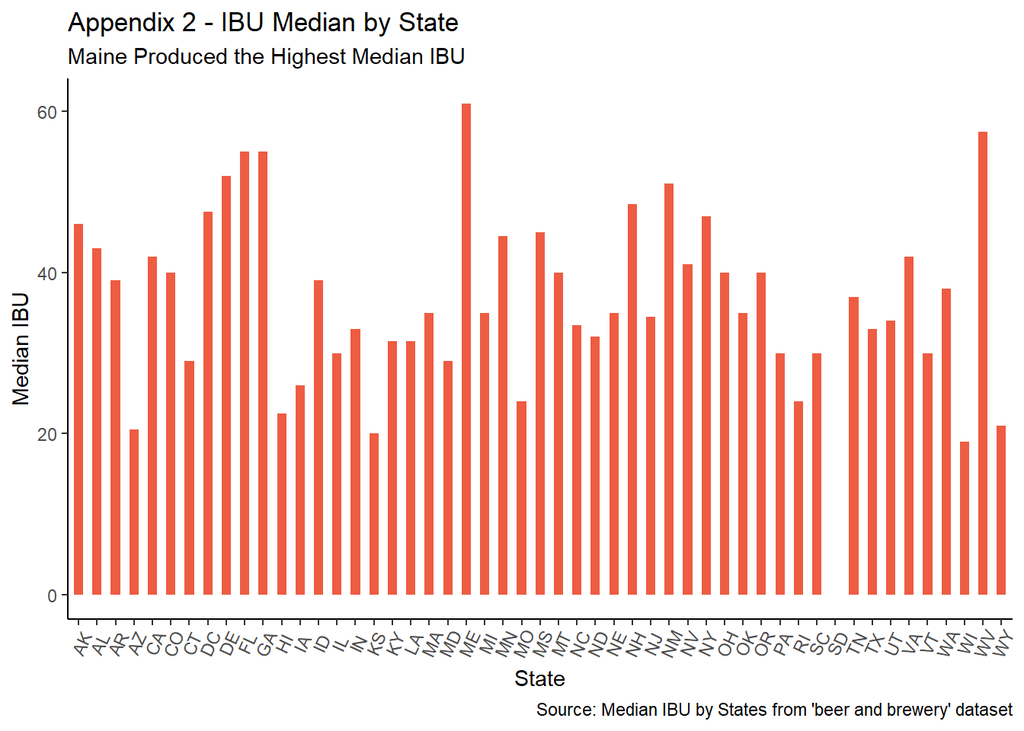

```r
ggplot(abv_ibu, aes(State, IBU)) + geom_bar(stat="identity", width = 0.5, fill="tomato2")+
    ylab("Median IBU")+
      labs(title="Appendix 2 - IBU Median by State",
           subtitle="Maine Produced the Highest Median IBU",
           caption="Source: Median IBU by States from 'beer and brewery' dataset") +
      theme(axis.text.x = element_text(angle=65, vjust=0.6))
```

We can tell that IBU median across state is a lot more variabile than ABV. with Maine beung the highest meidain IBU producer.

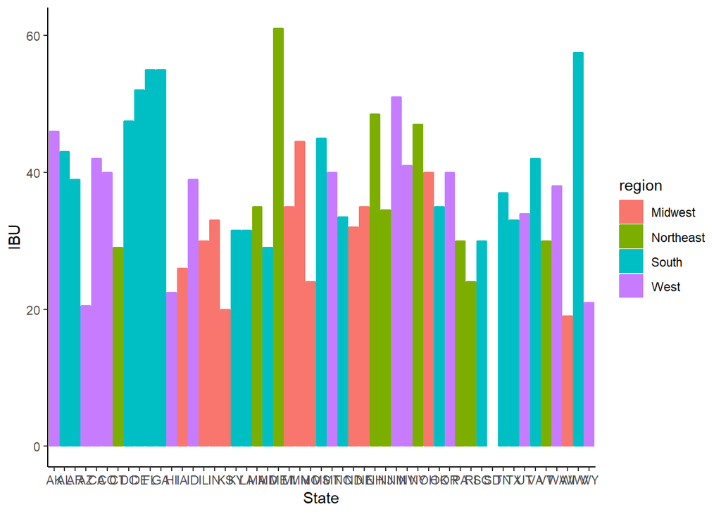

```r
ggplot(abv_ibu, aes(x = State, y = IBU)) +
  geom_bar(
    aes(color = region, fill = region),
    stat = "identity", position = position_stack()
    )
```

> 5. Which state has the maximum alcoholic (ABV) beer? Which state has the most bitter (IBU) beer?

```r
abv_ibu2 =df %>%
  group_by(State) %>%
  summarise_at(vars("ABV", "IBU"), funs(max(., na.rm=TRUE)))
#View(abv_ibu2)
```

We can tell that for `ABV` that [MAX]Colorado (0.128) other states with high ABV:Kentucky (0.125), Indiana (0.120) and New York (0.100) are hte highest

We can tell that for `IBU` that [MAX] Oregon (138) other states with high IBU: Virgina (135), Maine (130), Ohio (126).

> 6. Summary statistics for the ABV variable.

```r
print(sd(df$ABV, na.rm=TRUE))
```

```
## [1] 0.01354173
```

```r
summary(df$ABV)
```

```
##    Min. 1st Qu.  Median    Mean 3rd Qu.    Max.    NA's
## 0.00100 0.05000 0.05600 0.05977 0.06700 0.12800      62
```

above are the summary statistics. we can see that there are 62 NAs and the standard deviation is 0.0135

> dat%>% group_by(custid)%>% summarise(Mean=mean(value), Max=max(value), Min=min(value), Median=median(value), Std=sd(value))

```r
model = aov(ABV ~ IBU,data=df)
summary(model)
```

```
##               Df Sum Sq Mean Sq F value Pr(>F)
## IBU            1 0.1164  0.1164    1147 <2e-16 ***
## Residuals   1403 0.1424  0.0001
## ---
## Signif. codes:  0 '***' 0.001 '**' 0.01 '*' 0.05 '.' 0.1 ' ' 1
## 1005 observations deleted due to missingness
```

Utilizing the Anova variance F-test, for the `ABV ~ IBU` simple linear regression model, above provides sufficient evidence per the p-value <2e-16 indicating there is a relationship between `IBU` and `ABV`

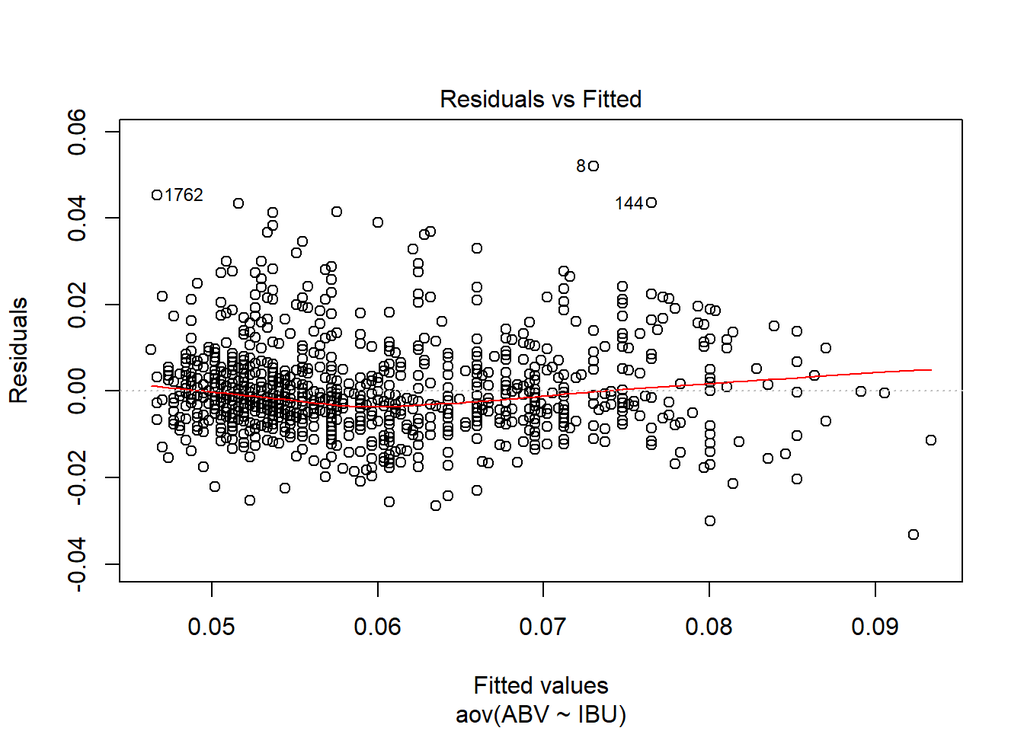

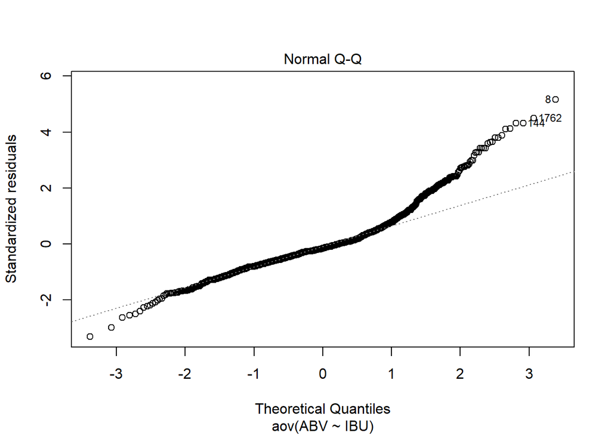

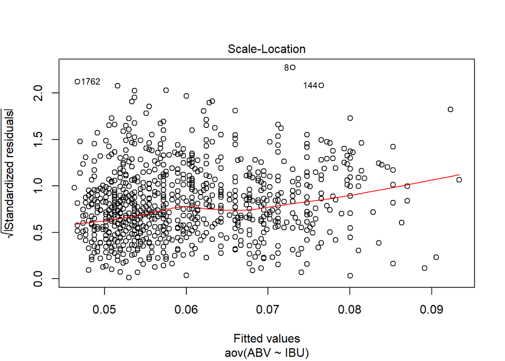

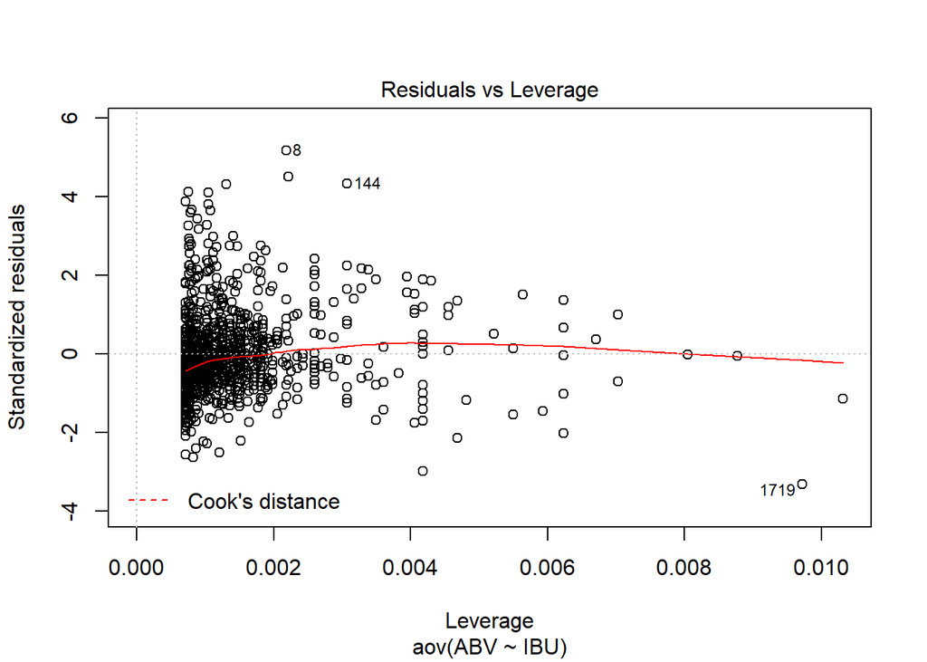

```r
plot(model)
```

### Person Crrelation

```r
#pearson corr
cor.test(df$ABV, df$IBU, method = 'pearson')
```

```
##
##  Pearson's product-moment correlation
##
## data:  df$ABV and df$IBU
## t = 33.863, df = 1403, p-value < 2.2e-16
## alternative hypothesis: true correlation is not equal to 0
## 95 percent confidence interval:
##  0.6407982 0.6984238
## sample estimates:
##       cor
## 0.6706215
```

Based on the Pearson R statistic for ABV and IBU are highly correlated.

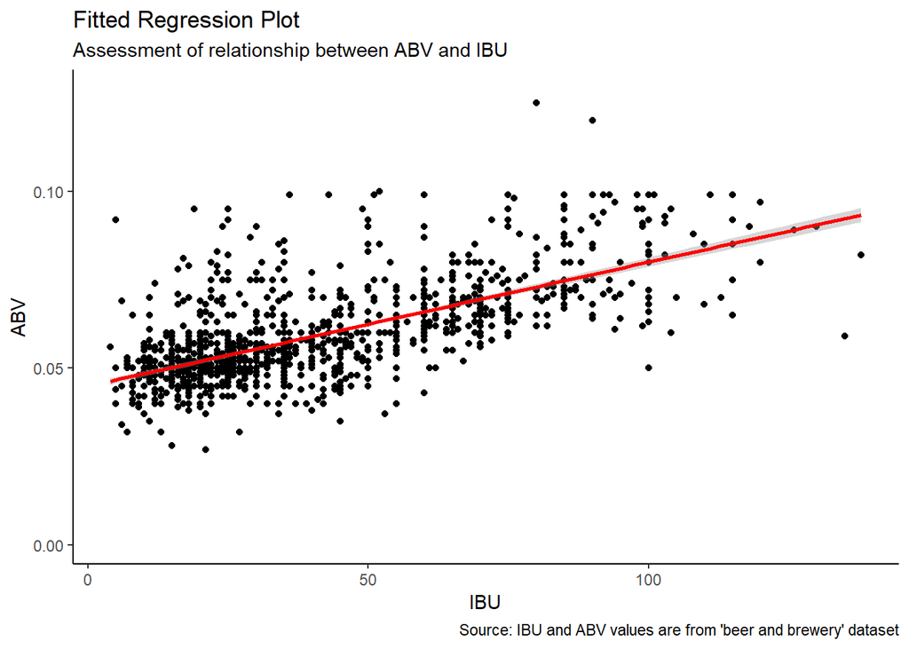

```r
ggplot(df, aes(x = IBU, y = ABV)) +
  geom_point() +
  stat_smooth(method = "aov", col = "red")+
      labs(title="Fitted Regression Plot",
           subtitle="Assessment of relationship between ABV and IBU",
           caption="Source: IBU and ABV values are from 'beer and brewery' dataset")
```

In the above fitted line plot plot we are able to confirm the linear relationship between ABV and IBU as IBU increases so does ABV. This supported the previous correaltion output.

below is a nicer plot used in the report. same result as above

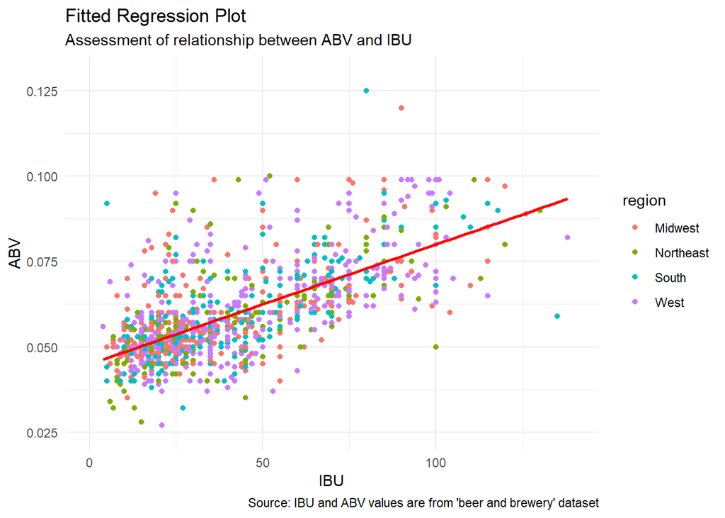

```r
library(ggplot2)
theme_set(theme_minimal())  # pre-set the bw theme.
# inspiration - http://r-statistics.co/Top50-Ggplot2-Visualizations-MasterList-R-Code.html

# Scatterplot
ggplot(df, aes(x = IBU, y = ABV)) +
  geom_point(aes(col=region)) +
  geom_smooth(method="aov", col = "red", se=F) +
  xlim(c(0, 140)) +
  ylim(c(0.025, 0.13)) +
  labs(title="Fitted Regression Plot",
           subtitle="Assessment of relationship between ABV and IBU",
       caption="Source: IBU and ABV values are from 'beer and brewery' dataset")
```